# 2025-topic-03-group-02-code

2025-05-16

# Group X Data Analysis Project

# Project Overview

### Goal:

- *Identification of RNA-Dependent Proteins* Build a robust analysis pipeline to identify proteins with altered distribution profiles after RNase treatment, using mass spectrometry data from 7,159 proteins isolated from synchronized mitotic HeLa cells.
- *Identification of RBPs specifically active during mitosis* Compare RNA-dependent protein profiles from synchronized mitotic cells with those from unsynchronized cells to find RBPs that are exclusively active during mitosis.
- *Screening for RBP complexes active in Mitosis* Investigate whether mitosis-specific RBPs co-segregate in control gradients aiming to detect both known and potentially novel RNA-dependent protein complexes (using different clustering methods).
- *Testing R-DeeP for further use in molecular weight predictions* Test if a protein’s position in the sucrose gradient correlates with its molecular weight, using linear regression to evaluate predictive potential.

## Libraries

```r
# General
library(tidyverse) # Collection of tidy data tools (ggplot2, dplyr, tidyr, etc.) for wrangling, plotting, and transforming datasets
library(tidyr)# Provides functions for transforming and reshaping data structures — used for pivot_wider to convert long-format correlation data into a wide matrix for heatmap input
library(pheatmap)# Generates customizable heatmaps; used to visualize the Spearman correlation matrix between all replicate-fraction combinations
library(glue) # Easy string construction with embedded variables and functions
library(ggplot2) # Various plots (elegant, versatile and easy to use)
library(dplyr) # For conditional logic with case_when inside plot aesthetics, also for filtering and selecting relevant data

# Clustering
library(dbscan) # Necessary for scaling in order to later run density based clustering

# Chunk Additional Data
library(httr) # Making API requests to UniProt (GET requests and response handling)
library(jsonlite) # Parsing JSON responses from the UniProt API
library(pbapply) # Applying functions with a progress bar
library(data.table) # Fast loading of large tables (CORUM) and simple grouping / restructuring of data using [i, j, by] syntax
```

# Loading MS-Data

```r
MS_Table <- read.table("Datasets/RDeeP_HeLa_Mitosis.csv", header = TRUE, row.names = 1, sep = ";")
```

# Data Cleanup

## Description of the Data - Lina

### Goal:

- Get a feeling for the dataset and decide on necessary clean-up steps

```r
glue("Number of proteins analysed /rows : {nrow(MS_Table)}")
```

```
## Number of proteins analysed /rows : 7159
```

```r
glue("Number of columns: {ncol(MS_Table)} (25 fractions with each 3 replicates for Ctrl and RNase treatment)")
```

```
## Number of columns: 150 (25 fractions with each 3 replicates for Ctrl and RNase treatment)
```

```r
glue("Classification of variables: {unique(sapply(MS_Table, class))}")
```

```
## Classification of variables: numeric
```

```r
glue("Any missing values: {any(is.na(MS_Table))}")
```

```
## Any missing values: FALSE
```

```r
glue("Overall minimum intensity: {min(MS_Table)}")
```

```
## Overall minimum intensity: 0
```

```r
glue("Overall maximum intensity: {max(MS_Table)}")
```

```
## Overall maximum intensity: 1514642849
```

# Normalization - Cihan, Sofia,Lina

### Goal:

- Generate a new dataframe with replicate-averaged intensity values,scaled so that each protein’s total intensity sums to 100 across all fractions (for Ctrl and RNase)
- Build a function to plot protein profiles using the normalized data
- Confirm experimental reproducibility by comparing intensity profiles across replicates

## Normalization of triplicates - Lina

```r
# Create a metadata dataframe with factor columns that map each MS_Table column to its experimental treatment, replicate, and fraction number
treatment <- factor(rep(c("Ctrl", "RNase"), each = 3, length.out = 150))
replicate <- factor(rep(c("Ctrl_Rep1", "Ctrl_Rep2", "Ctrl_Rep3", "RNase_Rep1","RNase_Rep2", "RNase_Rep3"),25))
fraction <- factor(rep(paste0("Fraction_", 1:25), each = 6))

data <- data.frame(rownames = colnames(MS_Table),treatment = treatment, replicate = replicate, fraction = fraction)

# Iterate over all fraction levels: for each fraction, select replicate columns of Ctrl and RNase, compute row-wise means and store them in previously created list
average.list <- list()

for (f in levels(fraction)) {

  cols.Ctrl <- which(fraction == f & treatment == "Ctrl")
  average.Ctrl <- rowMeans(MS_Table[,cols.Ctrl])
  average.list[[paste0("Ctrl_",f)]] <- average.Ctrl

  cols.RNase <- which(fraction == f & treatment == "RNase")
  average.RNase <- rowMeans(MS_Table[,cols.RNase])
  average.list[[paste0("RNase_",f)]] <- average.RNase
}

# Convert the list of averages to a data frame and restore rownames
MS_Table_Averages <- as.data.frame(average.list)
rownames(MS_Table_Averages) <- rownames(MS_Table)

# Reorder columns: alphabetic order of 'levels()' disrupts correct fraction sequence,so construct correct order manually (Ctrl_1 to Ctrl_25, then RNase_1 to RNase_25)
fractions <- paste0("Fraction_", 1:25)
ordered_names <- as.vector(rbind(
  paste0("Ctrl_", fractions),
  paste0("RNase_", fractions)
))

MS_Table_Averages <- MS_Table_Averages[, ordered_names]
```

## Plot showing variance of our data - Sofia

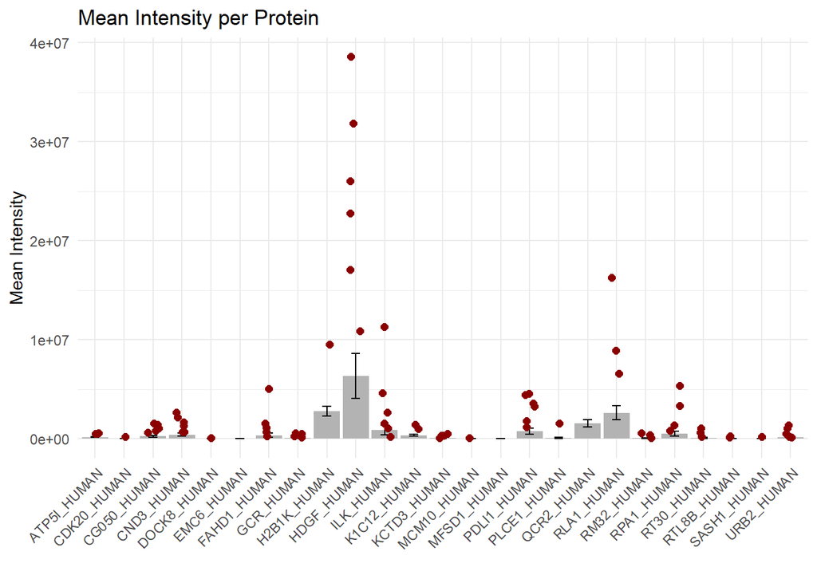

```r
library(dplyr)
# -------------- PART 1: Plot for standard deviation for all 7159 proteins from MS_Table_Averages for each fraction for the CTRL condition ----------



# 1. Select Ctrl columns using grep
ctrl_cols <- grep("^Ctrl_Fraction_", colnames(MS_Table_Averages), value = TRUE)

# 2. Randomly pick 25 proteins (rows)
set.seed(123)
selected <- sample(rownames(MS_Table_Averages), 25)
data <- MS_Table_Averages[selected, ctrl_cols]

# 3. Calculate mean and SE per protein (row-wise)
mean_vals <- apply(data, 1, mean, na.rm = TRUE)
se_vals <- apply(data, 1, function(x) sd(x, na.rm = TRUE) / sqrt(length(na.omit(x))))

# 4. Identify outliers for each protein
outliers <- lapply(1:nrow(data), function(i) {
  vals <- as.numeric(data[i, ])
  q1 <- quantile(vals, 0.25, na.rm = TRUE)
  q3 <- quantile(vals, 0.75, na.rm = TRUE)
  iqr <- q3 - q1
  out_idx <- which(vals < (q1 - 1.5 * iqr) | vals > (q3 + 1.5 * iqr))
  if (length(out_idx) > 0) {
    data.frame(Protein = rownames(data)[i],
               Intensity = vals[out_idx])
  }
})
outlier_df <- do.call(rbind, outliers)

# 5. Create summary dataframe
summary_df <- data.frame(
  Protein = rownames(data),
  Mean = mean_vals,
  SE = se_vals
)

# 6. Plot (no log scale)
ggplot(summary_df, aes(x = Protein, y = Mean)) +
  geom_bar(stat = "identity", fill = "gray70") +
  geom_errorbar(aes(ymin = Mean - SE, ymax = Mean + SE), width = 0.3) +
  geom_point(data = outlier_df, aes(x = Protein, y = Intensity),
             color = "darkred", size = 2, position = position_jitter(width = 0.2)) +
  labs(title = "Mean Intensity per Protein",
       y = "Mean Intensity", x = "") +
  theme_minimal() +
  theme(axis.text.x = element_text(angle = 45, hjust = 1))
```

## Normalization to 100 - Cihan

### Goal:

- Create a new dataframe in which the values for each protein are scaled so that the distribution within the Ctrl and RNase conditions each sums to 100
- For less variance between the fractions –> This allows comparison of distribution independent of absolute abundance

```r
# Split up Control and RNAse values
ctrl_cols <- grep("^Ctrl_", colnames(MS_Table_Averages))
rnase_cols <- grep("^RNase_", colnames(MS_Table_Averages))

# Normalization of each group to 100
ctrl_norm <- MS_Table_Averages[, ctrl_cols] / rowSums(MS_Table_Averages[, ctrl_cols]) * 100
rnase_norm <- MS_Table_Averages[, rnase_cols] / rowSums(MS_Table_Averages[, rnase_cols]) * 100

# Combine in one table
MS_Table_Norm <- cbind(ctrl_norm, rnase_norm)
MS_Table_Norm <- MS_Table_Norm[, colnames(MS_Table_Averages)]

# Verify the calculation with one example; the row sum should be ~200 (Ctrl 100% + RNAse 100%)
rowSums(MS_Table_Norm["1433B_HUMAN", ])
```

```
## 1433B_HUMAN
##         200
```

## Plotting a Protein - Lina

### Goal:

- Build a function to plot normalized intensity values of Ctrl and RNase across all fractions

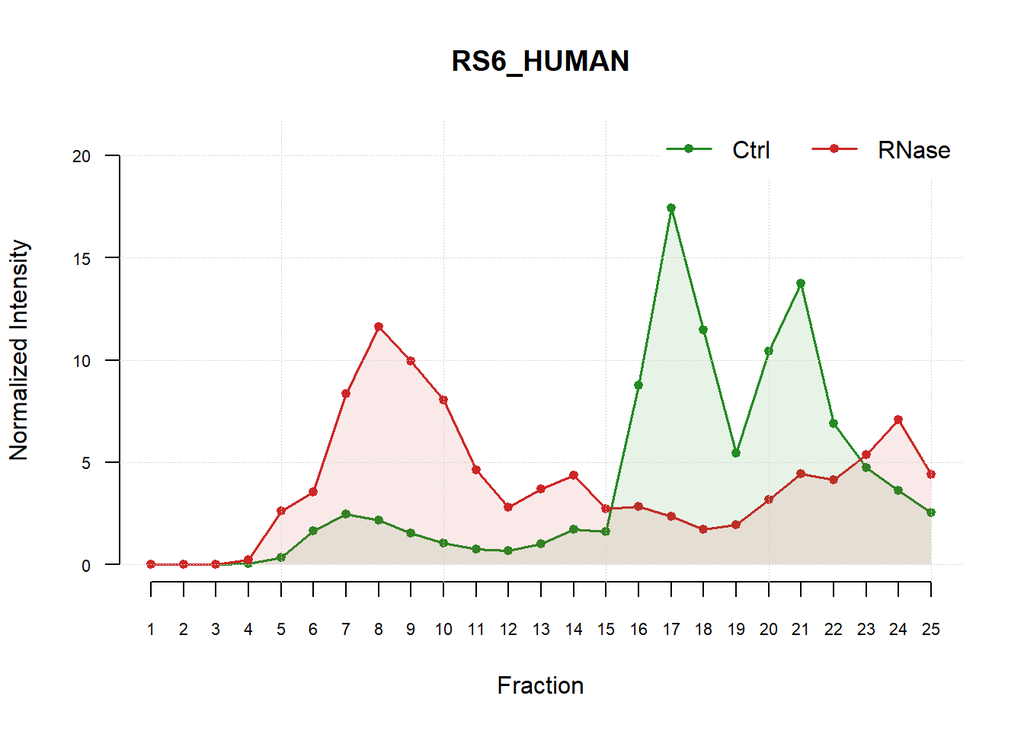

```r
plot_protein <- function(x) {

  # Extract data, define all variables and range of x- and y-axis
  protein_of_interest <- x
  protein_row <- MS_Table_Norm[rownames(MS_Table_Norm) == protein_of_interest, ]
  ctrl_values <- as.numeric(protein_row[seq(1, 49, by=2)])
  rnase_values <- as.numeric(protein_row[seq(2, 50, by=2)])
  fractions <- 1:25
  max_val <- max(ctrl_values, rnase_values, na.rm = TRUE)
  ylim_range <- c(0, max_val * 1.2)

  # Core plot function using crtl_values
  plot(fractions, ctrl_values, type="o", pch=20, lty=1, lwd = 1.5,  col="forestgreen", ylim= ylim_range,
       xlab="Fraction", ylab="Normalized Intensity", main= protein_of_interest, axes = FALSE)

  # Add line for rnase_values
  lines(fractions, rnase_values, type="o",pch =20, lty=1, lwd = 1.5,  col="firebrick3")

  # Color area under the curve
  polygon(c(fractions, rev(fractions)),
          c(ctrl_values, rep(0, length(ctrl_values))),
          col=adjustcolor("forestgreen", alpha.f=0.1), border=NA)

  polygon(c(fractions, rev(fractions)),
          c(rnase_values, rep(0, length(rnase_values))),
          col=adjustcolor("firebrick3", alpha.f=0.1), border=NA)

  # Add x- and y-axis with correct labels
  axis(1, at = 1:25, labels = 1:25, cex.axis = 0.7)
  axis(2, cex.axis = 0.7, las =2)
  grid(nx = NULL, ny = NULL, col = "lightgray", lty = "dotted", lwd = 0.8)

  # Add legend
  legend("topright", legend=c("Ctrl", "RNase"), col=c("forestgreen", "firebrick3"),
         lty=1, lwd = 1.5,  pch=20, bg = "white", bty = "o", box.col = NA, horiz = TRUE)
}

# Example
plot_protein("RS6_HUMAN")
```

## Reproducibility Analysis - Cihan, Sofia

### Goal:

- Assess reproducibility of MS-based protein measurements for both treatments
- Visualize how consistent protein ranking patterns are across all replicates and fractions
- We expect a diagonal showing our r = 1, while the other combinations should show lower correlation

```r
# Create empty dataframe for correlation
full_correlation_results <- data.frame(
  Treatment = character(),
  Replicate_1 = character(),
  Fraction_1 = character(),
  Replicate_2 = character(),
  Fraction_2 = character(),
  Spearman_r = numeric(),
  stringsAsFactors = FALSE
)

# Iterate over both Ctrl and RNase treatments
for (treatment in c("Ctrl", "RNase")) {

  # Create all possible rep-fraction combinations
  combo1 <- expand.grid(Rep = 1:3, Fraction = 1:25)
  combo2 <- expand.grid(Rep = 1:3, Fraction = 1:25)

  # Iterate for every possible combination
  for (i in 1:nrow(combo1)) {
    for (j in 1:nrow(combo2)) {

      rep1 <- combo1$Rep[i]
      frac1 <- combo1$Fraction[i]
      rep2 <- combo2$Rep[j]
      frac2 <- combo2$Fraction[j]

      # Find right column position
      col1 <- which(replicate == paste0(treatment, "_Rep", rep1) & fraction == paste0("Fraction_", frac1))
      col2 <- which(replicate == paste0(treatment, "_Rep", rep2) & fraction == paste0("Fraction_", frac2))

      # Calculate Spearman correlation
      cor_value <- cor(MS_Table[, col1], MS_Table[, col2], method = "spearman", use = "complete.obs")

      # Save results in dataframe
      full_correlation_results <- rbind(full_correlation_results, data.frame(
        Treatment = treatment,
        Replicate_1 = paste0("Rep", rep1),
        Fraction_1 = paste0("Fraction_", frac1),
        Replicate_2 = paste0("Rep", rep2),
        Fraction_2 = paste0("Fraction_", frac2),
        Spearman_r = cor_value
      ))
    }
  }
}


head(full_correlation_results)
```

```
##   Treatment Replicate_1 Fraction_1 Replicate_2 Fraction_2 Spearman_r
## 1      Ctrl        Rep1 Fraction_1        Rep1 Fraction_1  1.0000000
## 2      Ctrl        Rep1 Fraction_1        Rep2 Fraction_1  0.9997441
## 3      Ctrl        Rep1 Fraction_1        Rep3 Fraction_1  0.9995977
## 4      Ctrl        Rep1 Fraction_1        Rep1 Fraction_2  0.7563490
## 5      Ctrl        Rep1 Fraction_1        Rep2 Fraction_2  0.7504747
## 6      Ctrl        Rep1 Fraction_1        Rep3 Fraction_2  0.7501923
```

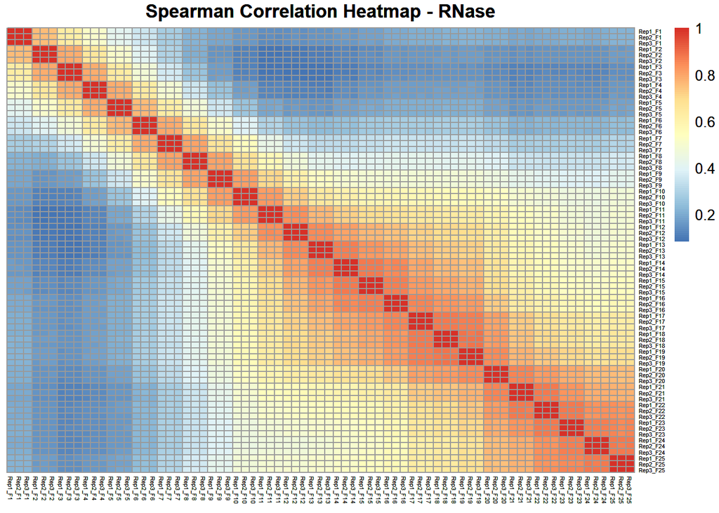

```r
# Create column for each axis
full_correlation_results <- full_correlation_results %>%
   mutate(Row = paste0(Replicate_1, "_F", gsub("Fraction_", "", Fraction_1)),
         Col = paste0(Replicate_2, "_F", gsub("Fraction_", "", Fraction_2)))

# We select treatment RNase for our first heatmap
treatment_to_plot_RNase <- "RNase"

# Filter table for selected treatment: RNase
heatmap_data_RNase <- full_correlation_results %>%
  filter(Treatment == treatment_to_plot_RNase) %>%
  select(Row, Col, Spearman_r)

# Convert into matrix
heatmap_matrix_RNase <- heatmap_data_RNase %>%
  pivot_wider(names_from = Col, values_from = Spearman_r, values_fill = NA) %>%
  column_to_rownames("Row") %>%
  as.matrix()

# Create heatmap for RNase treatment
print(pheatmap(heatmap_matrix_RNase,
         main = paste("Spearman Correlation Heatmap -", treatment_to_plot_RNase),
         cluster_rows = FALSE,
         cluster_cols = FALSE,
         show_rownames = TRUE,
         show_colnames = TRUE,
         fontsize_row = 4,
         fontsize_col = 4))
```

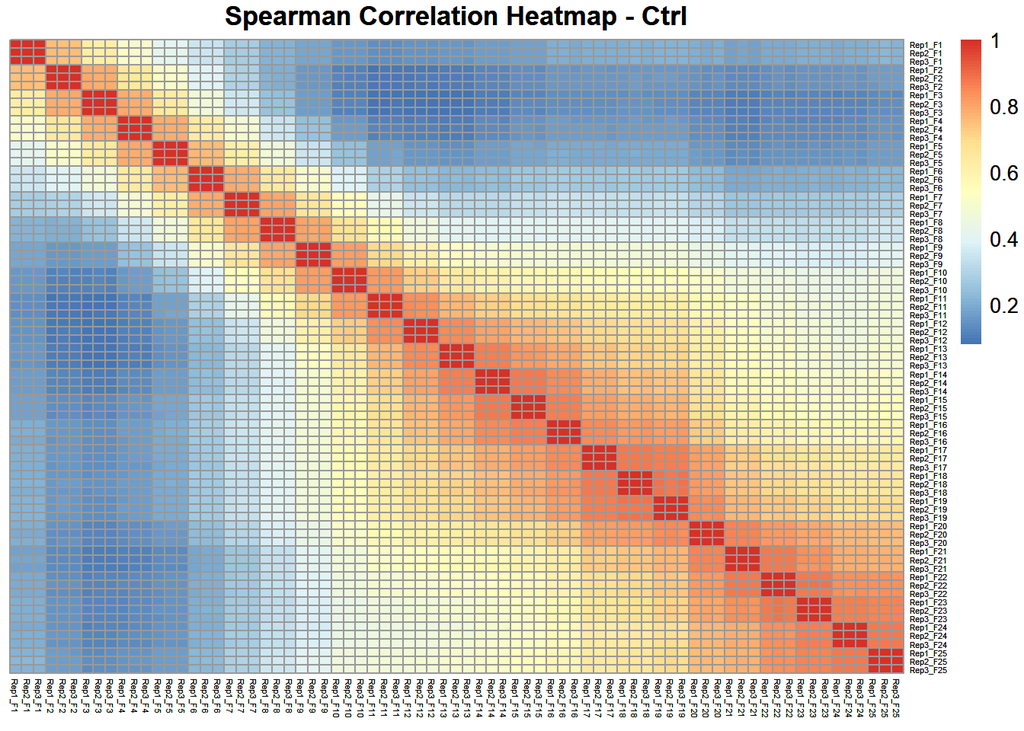

```r
# We select treatment Ctrl for our second heatmap
treatment_to_plot_Ctrl <- "Ctrl"

# Filter table for selected treatment: Ctrl
heatmap_data_Ctrl <- full_correlation_results %>%
  filter(Treatment == treatment_to_plot_Ctrl) %>%
  select(Row, Col, Spearman_r)

# Convert into matrix
heatmap_matrix_Ctrl <- heatmap_data_Ctrl %>%
  pivot_wider(names_from = Col, values_from = Spearman_r, values_fill = NA) %>%
  column_to_rownames("Row") %>%
  as.matrix()

# Create heatmap for Ctrl treatment
print(pheatmap(heatmap_matrix_Ctrl,
         main = paste("Spearman Correlation Heatmap -", treatment_to_plot_Ctrl),
         cluster_rows = FALSE,
         cluster_cols = FALSE,
         show_rownames = TRUE,
         show_colnames = TRUE,
         fontsize_row = 4,
         fontsize_col = 4))
```

# Data Analysis

### Goal:

- Identification of RNA-Dependent Proteins
- Identification of RBPs specifically active during mitosis

## Peak Detection in normalized Ctrl and RNase profiles - Lina

### Goal:

- Identify peaks in normalized intensity profiles (Ctrl and RNase)
- Extract number of peaks, their positions and heights

**NOTE:** Peak data is not used for RBP identification. This step is purely descriptive. However, Peak_Data is later used for clustering and linear regression analysis.

```r
# Define x axis
x <- 1:25

# Build function for peak detection using slope between fractions
# Detects internal peaks above a given threshold (default: 3% of max intensity)
# Note: Cannot detect peaks at positions 1 and 25 (manually handled below)
find_peaks <- function(y, threshold = max(y) * 0.03) {
  peaks <- which(diff(sign(diff(y))) == -2) + 1 # (+1 shifts index forward)
  peaks[y[peaks]>= threshold]
}

# Initialize list to collect results per protein and iterate over all proteins (rows in MS_Table_Norm)
peak_results <- list()

for (p in seq_len(nrow(MS_Table_Norm))) {

  # Extract normalized values for Ctrl and RNase
  row_vals <- as.numeric(MS_Table_Norm [p,])
  ctrl_vals <- row_vals[seq(1, 50, by =2)]
  rnase_vals <- row_vals[seq(2, 50, by=2)]

  results_row <- list()

  # Process both conditions in one loop
  for (cond in c("Ctrl", "RNase")) {
    y <- if (cond == "Ctrl") ctrl_vals else rnase_vals
    threshold <- max(y, na.rm = TRUE) * 0.03

    peaks <- find_peaks(y)

    # Manually check for peaks at positions 1 and 25
    if (length(peaks) == 0) {
      peaks <- numeric(0)
      }
    if (!is.na(y[1]) && !is.na(y[2]) && y[1] > y[2] && y[1] >= threshold) {
      peaks <- c(1, peaks)
      }
    if (!is.na(y[25]) && !is.na(y[24]) && y[25] > y[24] && y[25] >= threshold) {
      peaks <- c(peaks, 25)
    }
    # Fallback: If no peaks are detected at all, use global maximum
    if(length(peaks) == 0) {
      peaks <- which.max(y)
      }

    # Limit number of stored peaks to max. 6
    n_peaks <- min(length(peaks), 6)

    # Extract peak height and peak position
    y_peaks <- y[peaks]
    x_peaks <- x[peaks]

    # Store data for current protein (Number of peaks, peak heights and peak positions)
    results_row[[paste0("n_peaks_", cond)]] <- n_peaks

    for(n in seq_len(n_peaks)) {
    results_row[[paste0("peak", n, "_height_", cond)]] <- y_peaks[n]
    results_row[[paste0("peak", n, "_position_", cond)]] <- x_peaks[n]
    }
  }
  # Store result for current protein
  peak_results[[p]] <- results_row
}
# Fill missing values with NAs to allow binding all rows together
rows_df <- lapply(peak_results, function(x){
  columns <- c("peak1_height", "peak1_position",
               "peak2_height", "peak2_position",
               "peak3_height", "peak3_position",
               "peak4_height", "peak4_position",
               "peak5_height", "peak5_position",
               "peak6_height", "peak6_position")
  for (cond in c("Ctrl", "RNase")) {
    for (c in columns) {
      key <- paste0(c, "_", cond)
      if(!(key %in% names(x))) {
        x[[key]] <- NA
      }
    }
  }
  as.data.frame(x)
})

# Combine all protein results into one data frame
Peak_Data <- do.call(rbind, rows_df) #do.call bind used because rows_df is a list of dataframes
rownames(Peak_Data) <- rownames(MS_Table_Norm)

# Reorder columns: first n_peaks, then all peak heights and positions (Ctrl & RNase)
order <- c("n_peaks_Ctrl", "n_peaks_RNase")

for (i in 1:6) {
  order <- c(order,
                 paste0("peak", i, "_height_Ctrl"),
                 paste0("peak", i, "_position_Ctrl"),
                 paste0("peak", i, "_height_RNase"),
                 paste0("peak", i, "_position_RNase"))
}

Peak_Data <- Peak_Data[, order]
```

# Shift Characteristics - Lina, Sofia, Cihan

### Goal:

- Quantify and summarize positional shifts in protein distribution between Ctrl and RNase conditions using center of mass (CoM) calculation as a weighted average
- Further shift characterization with:

  Shift distance: difference between CoM_Ctrl and CoM_RNase

  Shift direction: +1 = left-shift, –1 = right-shift, 0 = no shift

**NOTE:** CoM-based shift calculations is later repeated per replicate and used for statistical testing (t-test) to identify significantly shifting RBPs.

```r
# Initialize result vectors (one value per protein)
CoM_Ctrl <- numeric(nrow(MS_Table_Norm))
CoM_RNase <- numeric(nrow(MS_Table_Norm))
shift_distance <- numeric(nrow(MS_Table_Norm))
shift_direction <- numeric(nrow(MS_Table_Norm))

# Iterate over all proteins and calculate shift using center of mass
for (p in seq_len(nrow(MS_Table_Norm))) {

   # Extract normalized intensities for Ctrl and RNase
  row_vals <- as.numeric(MS_Table_Norm [p,])
  ctrl_vals <- row_vals[seq(1, 50, by =2)]
  rnase_vals <- row_vals[seq(2, 50, by=2)]

  # Calculate Center of Mass for both conditions
  CoM_Ctrl[p] <- sum(ctrl_vals * x) / sum(ctrl_vals)
  CoM_RNase[p] <- sum(rnase_vals * x) / sum(rnase_vals)

  # Compute shift distance and direction
  shift_distance[p] <- CoM_Ctrl[p] - CoM_RNase[p]
  shift_direction[p] <- sign(shift_distance[p])
}

# Store results into a single dataframe
Shift_Data <- data.frame(
  CoM_Ctrl = CoM_Ctrl,
  CoM_RNase = CoM_RNase,
  shift_distance = shift_distance,
  shift_direction = shift_direction,
  row.names = rownames(MS_Table_Norm))
```

## T-Test

### 1. Normalization of whole MS_Table to 100 - Cihan

```r
# Split up all Ctrl and RNAse values and their individual Reps
ctrl_cols_t1 <- grep("_Ctrl_Rep1", colnames(MS_Table))
ctrl_cols_t2 <- grep("_Ctrl_Rep2", colnames(MS_Table))
ctrl_cols_t3 <- grep("_Ctrl_Rep3", colnames(MS_Table))
RNase_cols_t1 <- grep("_RNase_Rep1", colnames(MS_Table))
RNase_cols_t2 <- grep("_RNase_Rep2", colnames(MS_Table))
RNase_cols_t3 <- grep("_RNase_Rep3", colnames(MS_Table))

# Normalization of each group to 100
ctrl_norm_t1 <- MS_Table[, ctrl_cols_t1] / rowSums(MS_Table[, ctrl_cols_t1]) * 100
ctrl_norm_t2 <- MS_Table[, ctrl_cols_t2] / rowSums(MS_Table[, ctrl_cols_t2]) * 100
ctrl_norm_t3 <- MS_Table[, ctrl_cols_t3] / rowSums(MS_Table[, ctrl_cols_t3]) * 100
RNase_norm_t1 <- MS_Table[, RNase_cols_t1] / rowSums(MS_Table[, RNase_cols_t1]) * 100
RNase_norm_t2 <- MS_Table[, RNase_cols_t2] / rowSums(MS_Table[, RNase_cols_t2]) * 100
RNase_norm_t3 <- MS_Table[, RNase_cols_t3] / rowSums(MS_Table[, RNase_cols_t3]) * 100

# Combine in one table
Norm_Data_for_t <- cbind(ctrl_norm_t1, RNase_norm_t1, ctrl_norm_t2, RNase_norm_t2, ctrl_norm_t3, RNase_norm_t3)

# Arrange in the preferred order
fractions <- 1:25
reps <- 1:3
conditions <- c("Ctrl", "RNase")


ordered_names <- c()

for (fraction in fractions) {
  for (rep in reps) {
    for (condition in conditions) {
      name <- paste0("Fraction", fraction, "_", condition, "_Rep", rep)
      ordered_names <- c(ordered_names, name)
    }
  }
}

Norm_Data_for_t <- Norm_Data_for_t[, ordered_names]

# Verify the calculation with one example; the row sum should be ~600 (3*Ctrl 100% + 3*RNAse 100%)
rowSums(Norm_Data_for_t["1433B_HUMAN", ])
```

```
## 1433B_HUMAN
##         600
```

### 2. Calculation of Center of mass (CoM) - Sofia

```r
# Setup
fractions <- 1:25
conditions <- c("Ctrl", "RNase")
replicates <- c("Rep1", "Rep2", "Rep3")

results_com <- list()

# Loop through conditions and replicates ( runs 6 times for all combinations)
for (cond in conditions) {
  for (rep in replicates) {

    # Single regex pattern to match all 25 fraction columns for this condition & replicate
    pattern <- paste0("^Fraction[0-9]+_", cond, "_", rep, "$") # defines a pattern
    cols <- grep(pattern, colnames(Norm_Data_for_t), value = TRUE) # chooses pattern from colums (matching)

    # Subset and sort by fraction number
    subdata <- Norm_Data_for_t[, cols] # chooses all columns
    subdata <- subdata[, order(as.numeric(gsub("Fraction(\\d+)_.*", "\\1", cols)))] # putting into the right order as Com assumes coloum 1 = fraction 1

    # Center of mass calculation
    com <- apply(subdata, 1, function(x) sum(x * fractions) / sum(x)) # function (across rows)

    # Store result
    results_com[[paste(cond, rep, sep = "_")]] <- com # adds result from com to each cond/ rep, separates with _
  }
}

# Convert list to data frame
CoM_Data_for_t <- as.data.frame(results_com)

rownames(CoM_Data_for_t) <- rownames(Norm_Data_for_t) # apply rownames from df to new df
```

### 3. Calculating Shift-Values for T-Test - Lina

```r
# For each protein, subtract the RNase CoM from the corresponding Ctrl CoM across all three replicates to obtain replicate-wise shift distances.
# Columns 1–3 = Ctrl_Rep1–3, Columns 4–6 = RNase_Rep1–3 (in CoM_Data_for_t)
Shift_Data_for_t <- data.frame(
  shift_distance_rep1 = CoM_Data_for_t[, 1] - CoM_Data_for_t[, 4],
  shift_distance_rep2 = CoM_Data_for_t[, 2] - CoM_Data_for_t[, 5],
  shift_distance_rep3 = CoM_Data_for_t[, 3] - CoM_Data_for_t[, 6],
  row.names = rownames(CoM_Data_for_t)
)

# Count how many missing values (NA) are present across all shift distances. (proteins where CoM could not be calculated in at least one replicate)
sum(is.na(Shift_Data_for_t))
```

```
## [1] 13
```

### 4. T-Test - Cihan

#### Goal:

- Statistically test whether proteins show a significant left-shift in their center of mass (CoM) distribution in RNase vs. Ctrl, indicating RNA-dependent localization.
- This is done by:
  1. Applying the Shapiro-Wilk test to firstly ensure, that shift values of the replicates are normally distributed before running the t-test.
  2. Testing if the shift distance is significantly greater than 1 using a one-sided t-test.
- Significant hits are categorized as RBPs.

```r
# Create empty columns for statistical test results
Shift_Data$shapiro_p <- NA
Shift_Data$normal_distributed <- NA
Shift_Data$p_value_ttest_filtered <- NA
Shift_Data$significant_ttest_filtered <- NA

# Iterate over all proteins
for (protein in rownames(Shift_Data_for_t)) {

  # Extract shift distances for each replicate
  shift_values <- as.numeric(Shift_Data_for_t[protein, c("shift_distance_rep1", "shift_distance_rep2", "shift_distance_rep3")])

  # Make sure that no NAs are present
  if (all(!is.na(shift_values))) {

    # Check if all values are identical (no variance)
    if (length(unique(shift_values)) == 1) {

      # Set normal distribution to TRUE if no variance is present
      Shift_Data[protein, "shapiro_p"] <- NA
      Shift_Data[protein, "normal_distributed"] <- TRUE

    } else {

      # Perform Shapiro-Wilk test to check for normal distribution
      shapiro_result <- shapiro.test(shift_values)
      Shift_Data[protein, "shapiro_p"] <- shapiro_result$p.value
      Shift_Data[protein, "normal_distributed"] <- shapiro_result$p.value >= 0.05
    }

    # Perform one-sided t-test if data is normal distributed
    if (Shift_Data[protein, "normal_distributed"] == TRUE) {

      test_result <- t.test(shift_values, mu = 1, alternative = "greater")

      Shift_Data[protein, "p_value_ttest_filtered"] <- test_result$p.value
      Shift_Data[protein, "significant_ttest_filtered"] <- ifelse(test_result$p.value < 0.05, TRUE, FALSE)

    } else {
      # No t-test applied if data is not normal distributed
      Shift_Data[protein, "p_value_ttest_filtered"] <- NA
      Shift_Data[protein, "significant_ttest_filtered"] <- NA
    }
  }
}

# Summary of proteins regarding normal distribution
table(Shift_Data$normal_distributed, useNA = "ifany")
```

```
##
## FALSE  TRUE  <NA>
##   304  6848     7
```

```r
# Summary of proteins regarding significance of t-test
table(Shift_Data$significant_ttest_filtered, useNA = "ifany")
```

```
##
## FALSE  TRUE  <NA>
##  6054   794   311
```

## Plot T-Test Results - Lina

### Goal:

- Plot t-test results by visualizing CoM positions in Ctrl vs. RNase

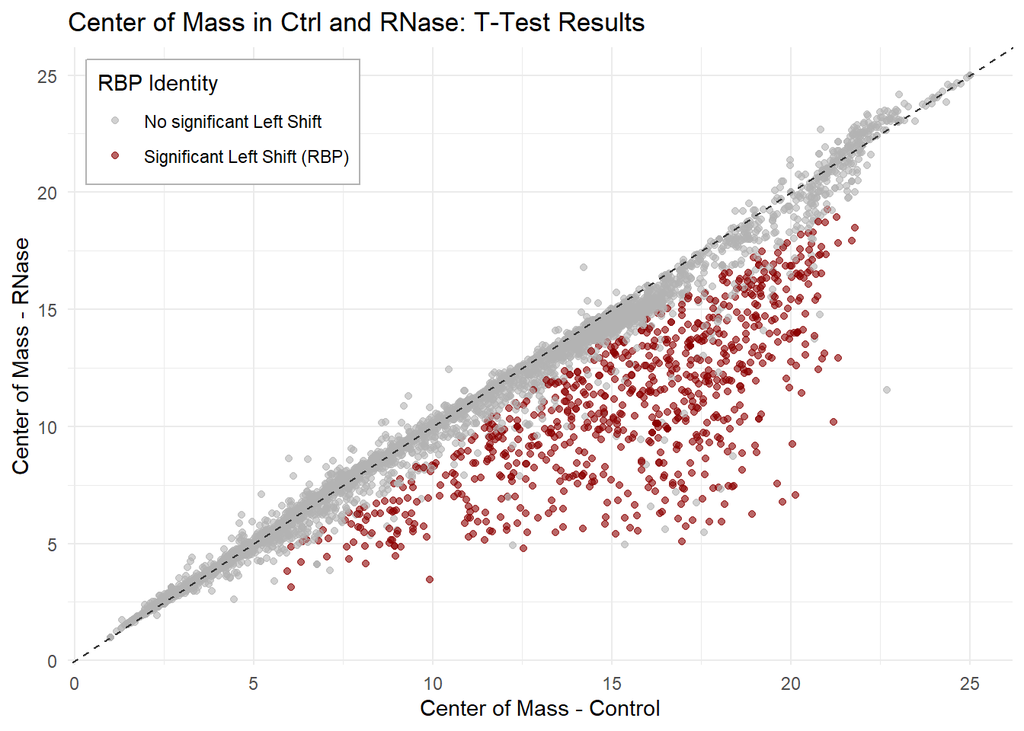

```r
# Create scatter plot of CoM values in Ctrl (x) vs. RNase (y) for all proteins
# Color points based on t-test result (significant or not)
ggplot(Shift_Data, aes(x = `CoM_Ctrl`, y = `CoM_RNase`, color = case_when(
  `significant_ttest_filtered` ~ "Significant Left Shift (RBP)",
    TRUE ~ "No significant Left Shift"
  ))) +
  geom_point(alpha = 0.6) +
  geom_abline(slope = 1, intercept = 0, linetype = "dashed", color = "gray20") +
  scale_color_manual(name = "RBP Identity",values = c(
    "Significant Left Shift (RBP)" = "darkred",
    "No significant Left Shift" = "gray70"
  ))+
  labs(title = "Center of Mass in Ctrl and RNase: T-Test Results",
       x = "Center of Mass - Control",
       y = "Center of Mass - RNase") +
  theme_minimal()+
  theme(
    legend.position = c(0.02, 0.98),
    legend.justification = c("left", "top"),
    legend.background = element_rect(fill = "white",color = "gray70")
  )
```

## Validation of T-Test with UniProt Data - Lina

### Goal:

Assess the validity of our T-test-based identification of RNA-binding proteins (RBPs), by comparing the results with annotated human RBPs from UniProt.

This includes:

- Overlap analysis between our tested proteins and known UniProt RBPs
- Calculation of a hit rate (percentage of known RBPs detected as T-test positives)
- Validation with literature-supported positive and negative control proteins

```r
# Load annotated RNA-binding proteins (Keyword KW-0694) from UniProt (human-specific)
uniprot_rbps <- read.delim("Databanks/uniprotkb_KW_0694_AND_model_organism_96_2025_07_04.tsv",
                           header = TRUE, sep = "\t", stringsAsFactors = FALSE)

# Extract UniProt entry names (used for matching)
known_rbps <- uniprot_rbps$Entry.Name
glue("Number of known RBPs in UniProt: {length(known_rbps)}")
```

```
## Number of known RBPs in UniProt: 3114
```

```r
# Extract RBP candidates identified by T-test
t_test_positives <- rownames(
  Shift_Data[Shift_Data$significant_ttest_filtered == TRUE &
               !is.na(Shift_Data$significant_ttest_filtered), ])

# Determine overlap: known RBPs present in our dataset
overlap_MS_Table <- intersect(rownames(MS_Table), known_rbps)
glue("Number of UniProt RBPs tested with R-DeeP: {length(overlap_MS_Table)}")
```

```
## Number of UniProt RBPs tested with R-DeeP: 543
```

```r
# Determine overlap: known RBPs that were also T-test positive
overlap_t_test <- intersect(t_test_positives, known_rbps)
glue("Number identified as RBPs (T-Test positive): {length(overlap_t_test)}")
```

```
## Number identified as RBPs (T-Test positive): 230
```

```r
glue("Hit rate: {round(length(overlap_t_test)/length(overlap_MS_Table)*100, 2)}%")
```

```
## Hit rate: 42.36%
```

```r
# Determine number of identified RBS not listed as RBP in UniProt
novel_candidates <- t_test_positives[!t_test_positives %in% known_rbps]
glue("Novel candidates identified as RBP but not listed in UniProt: {(length(novel_candidates))}")
```

```
## Novel candidates identified as RBP but not listed in UniProt: 564
```

```r
# Positive Control Validation

  # RBM10, SMN1, and FMR1 are well-documented RBPs (literature-supported)
  pos_controls <- c("RBM10_HUMAN", "SMN_HUMAN", "FMR1_HUMAN")

  # Check whether they are in our dataset and classified as T-test positives
  pos_df <- data.frame(
    Protein_Positive_Control = pos_controls,
    InDataset = pos_controls %in% rownames(MS_Table),
    TTest = pos_controls %in% t_test_positives)
  print(pos_df)
```

```
##   Protein_Positive_Control InDataset TTest
## 1              RBM10_HUMAN      TRUE  TRUE
## 2                SMN_HUMAN      TRUE  TRUE
## 3               FMR1_HUMAN      TRUE  TRUE
```

```r
# Positive Control Validation

  # ACTB, SDHB, and COX4I1 are typically not considered RNA-binding (negative controls)
  neg_controls <- c("ACTB_HUMAN", "SDHB_HUMAN", "COX41_HUMAN")

  # Same check as above for negatives
  neg_df <- data.frame(
    Protein_Negative_Control = neg_controls,
    InDataset = neg_controls %in% rownames(MS_Table),
    TTest = neg_controls %in% t_test_positives)
  print(neg_df)
```

```
##   Protein_Negative_Control InDataset TTest
## 1               ACTB_HUMAN      TRUE FALSE
## 2               SDHB_HUMAN      TRUE FALSE
## 3              COX41_HUMAN      TRUE FALSE
```

### Evaluation of T-Test Limitations - Lina, Cihan, Sofia

### Goal:

This section investigates potential false negatives from the T-test-based RBP identification.

- Explore cases where known RBPs were not classified as significant and examine possible causes.
- Manual inspection of different samples of 40 proteins each:
  1. Not identified RBPs to assess false negative rate.
  2. T-Test positives to assess false positive rate.
  3. Borderline cases (0.05 > p-value > 0.045)

**NOTE:** Here only samples of 10 proteins are shown, for visibility in html

```r
# Identify known UniProt RBPs not found by T-Test
not_identified <- known_rbps[! known_rbps %in% t_test_positives & known_rbps %in% rownames(MS_Table)]

# Total "missed" RBPs present in dataset
glue("RNA-binding/-interacting proteins (UniProt) analyzed but not detected in our data: {length(not_identified)}")
```

```
## RNA-binding/-interacting proteins (UniProt) analyzed but not detected in our data: 313
```

```r
# Analyze potential causes
shapiro_failed <- Shift_Data[is.na(Shift_Data$shapiro_p),]
percentage_shapiro_failed <- sum(is.na(Shift_Data[not_identified, "shapiro_p"])) /length(not_identified) *100
glue("Number of Proteins, that were excluded, because shapiro results where NA: {nrow(shapiro_failed)}")
```

[output not shown]

```r
glue("Approx. Percentage of not identified RBPs that where lost in Shapiro-Wilk test: {round(percentage_shapiro_failed, 1)} %")
```

[output not shown]

```r
normality_failed <- Shift_Data[Shift_Data$normal_distributed == FALSE,]
percentage_normality_failed <- sum(Shift_Data[not_identified, "normal_distributed"] == FALSE) / length(not_identified) *100
glue("Number of Proteins, that where excluded, because replicates wheren't normally distributed: {nrow(normality_failed)}")
```

```
## Number of Proteins, that where excluded, because replicates wheren't normally distributed: 311
```

```r
glue("Approx. Percentage of not identified RBPs that where lost in normality test: {round(percentage_normality_failed, 1)} %")
```

```
## Approx. Percentage of not identified RBPs that where lost in normality test: 9.9 %
```

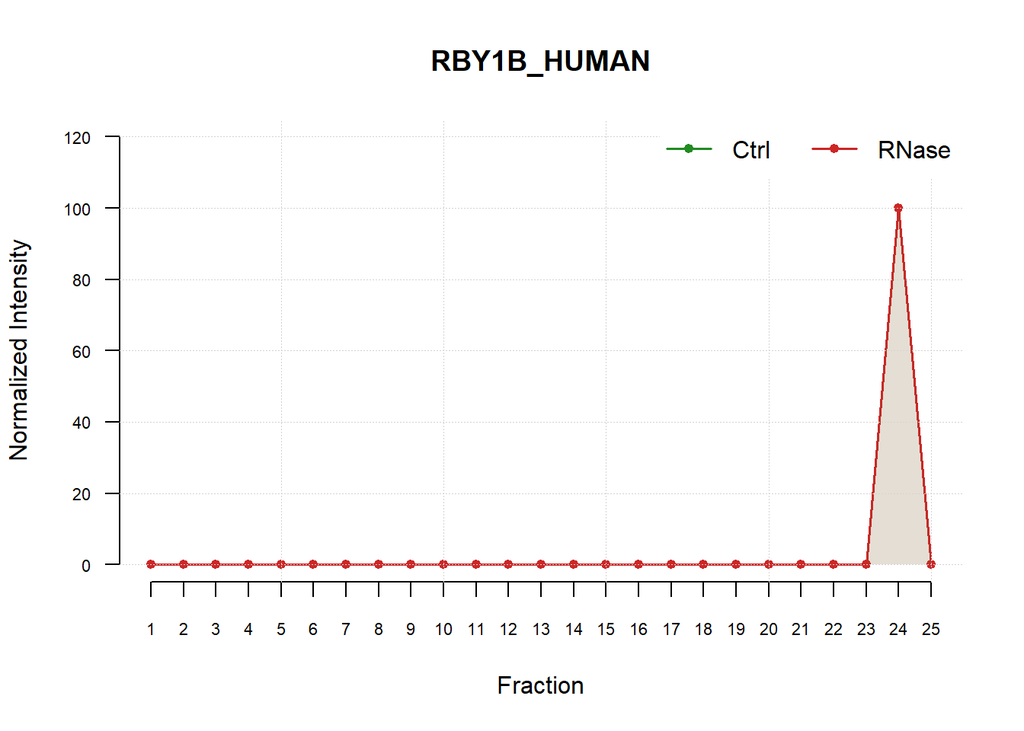

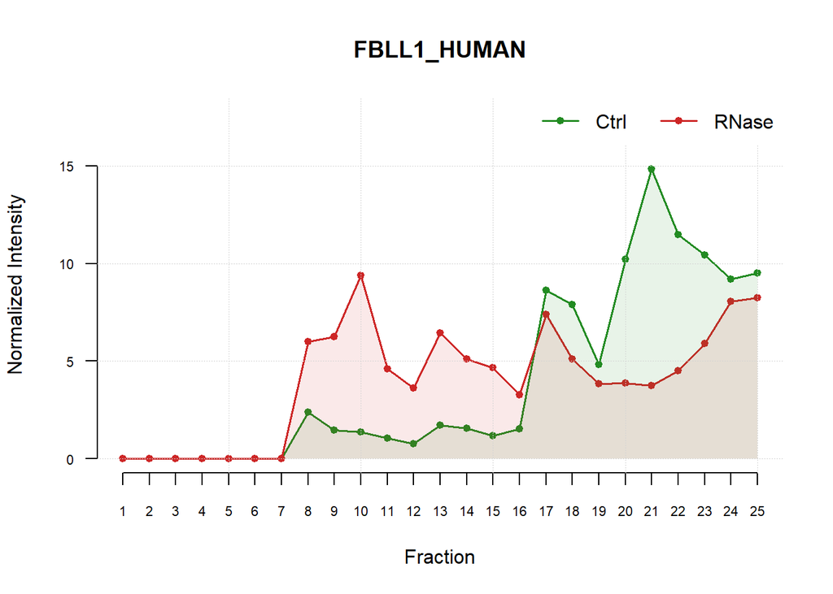

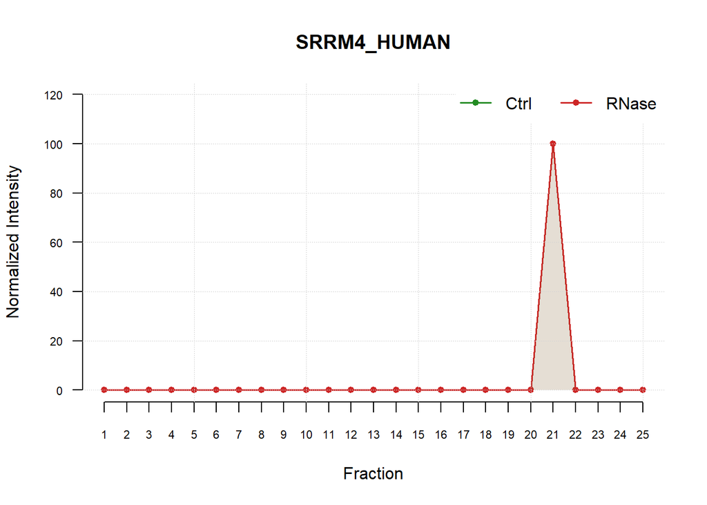

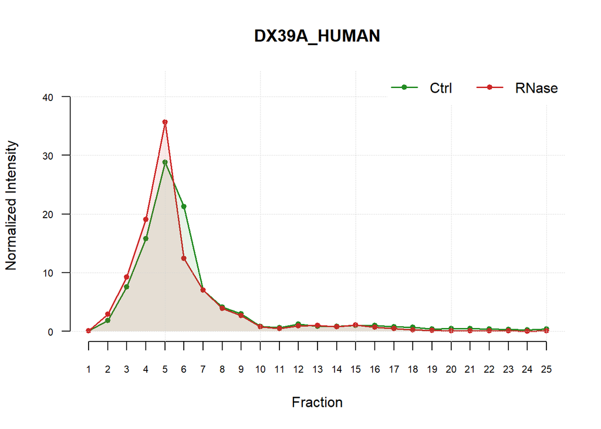

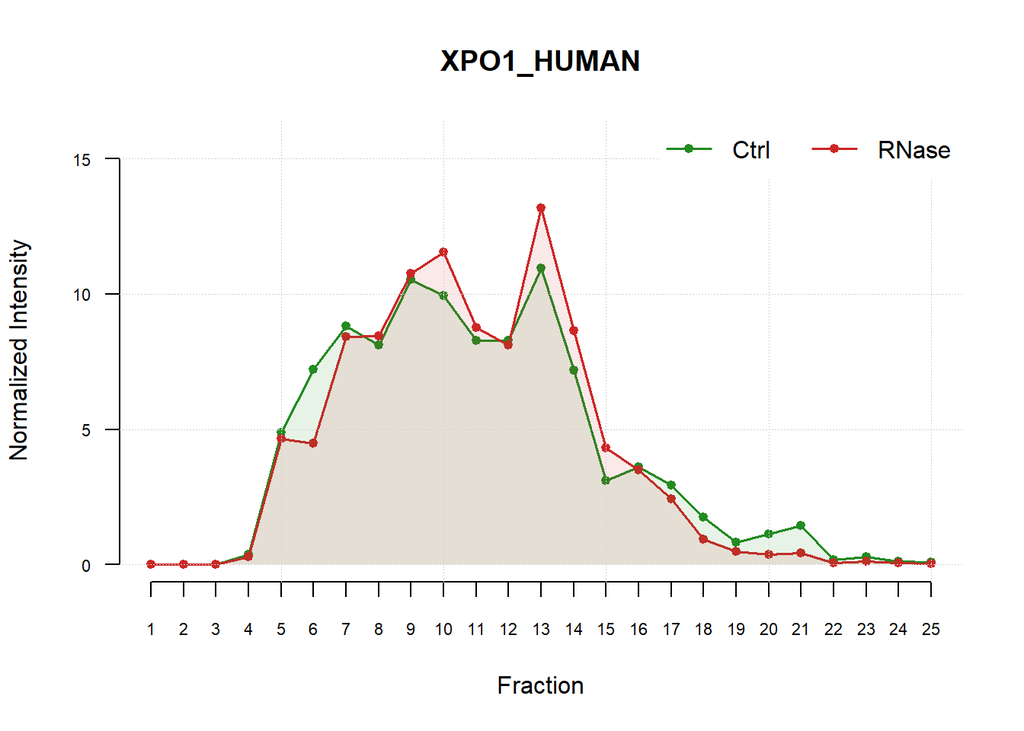

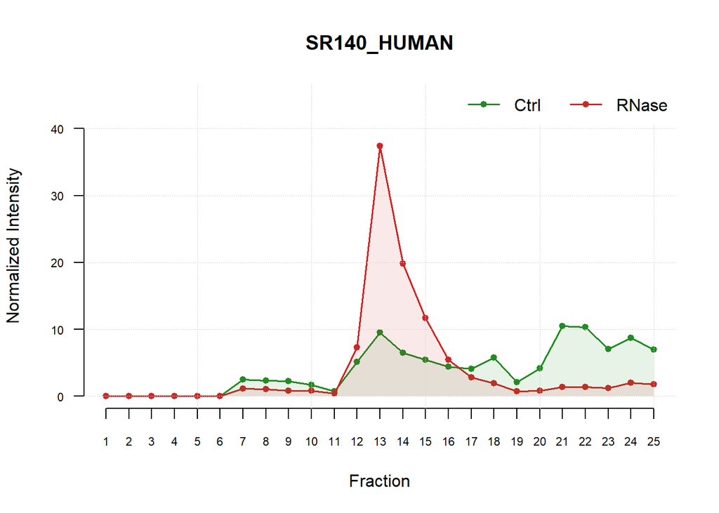

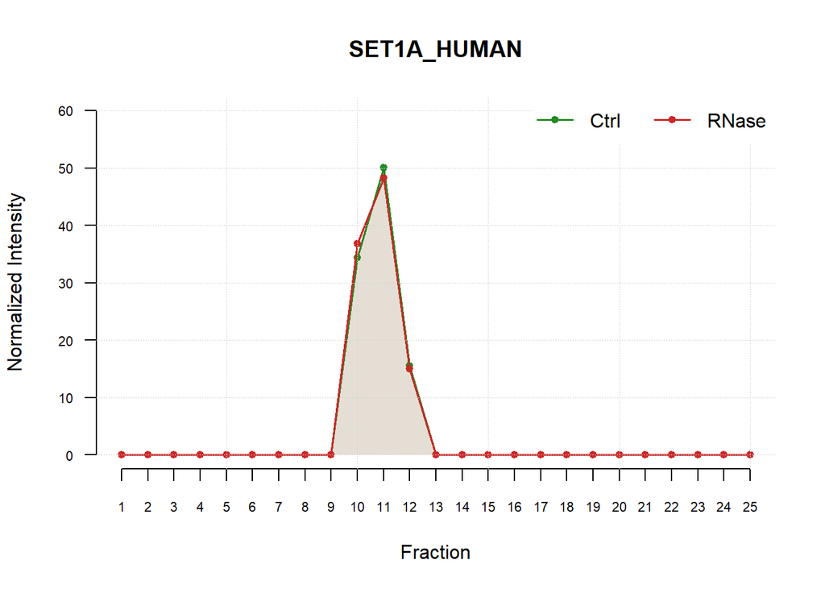

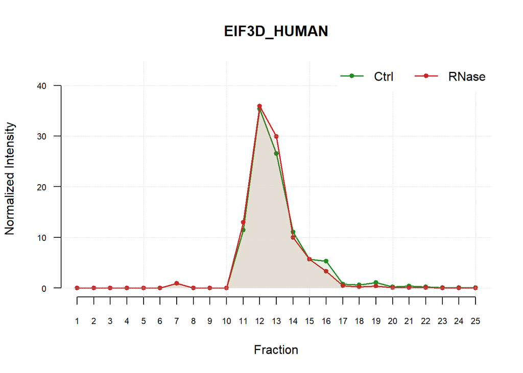

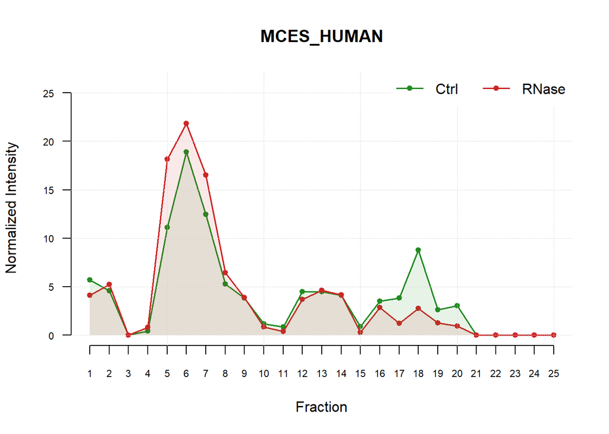

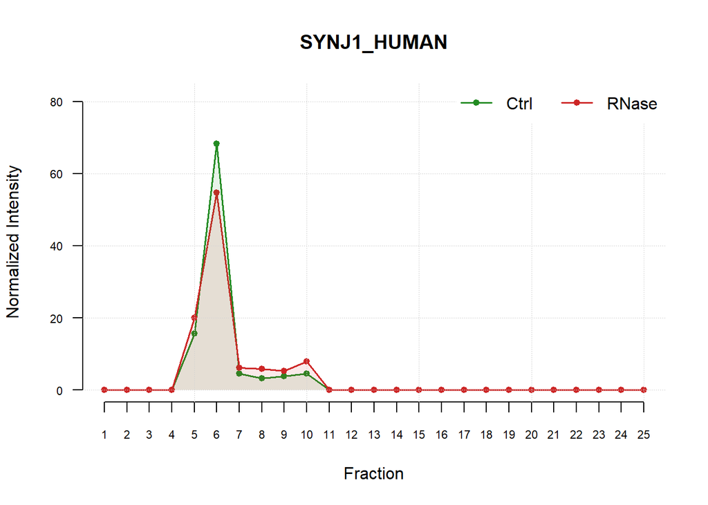

```r
#Visual inspection of a sample of non-identified proteins
sample_not_identified <- head( not_identified, 10)
for (s in sample_not_identified ){
  plot_protein(s)
}
```

```r
glue("Manual inspection of 40 non-identified RBPs suggests a false negative rate of approximately 13% (5 out of 40) within the testable subset (visual shift despite test results)")
```

```
## Manual inspection of 40 non-identified RBPs suggests a false negative rate of approximately 13% (5 out of 40) within the testable subset (visual shift despite test results)
```

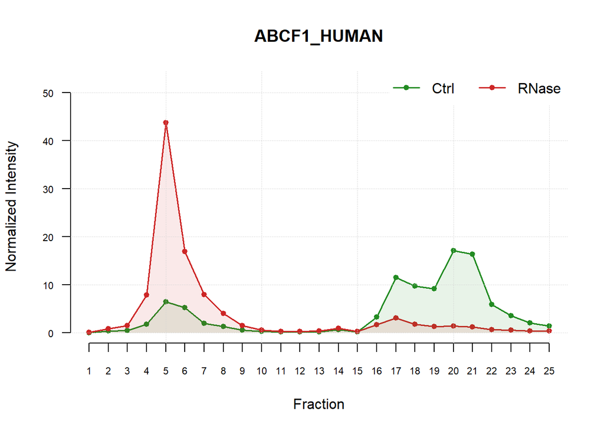

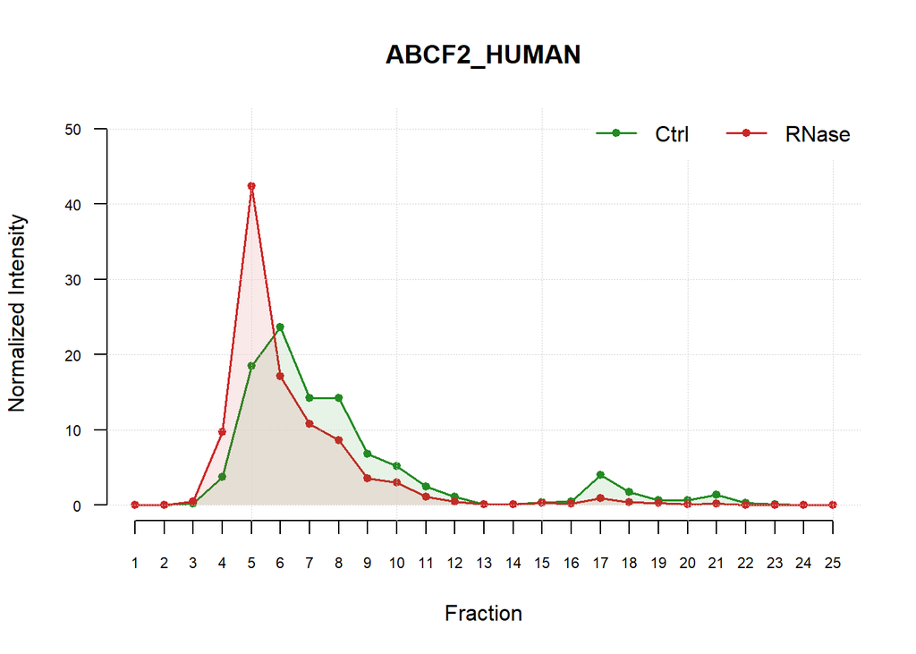

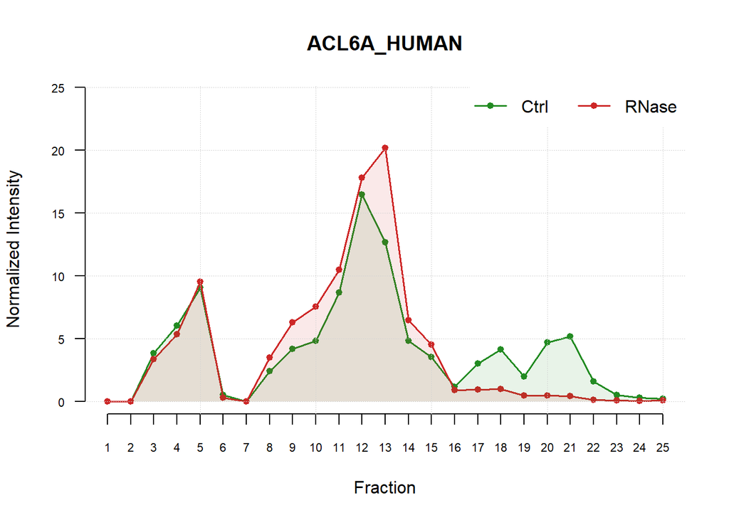

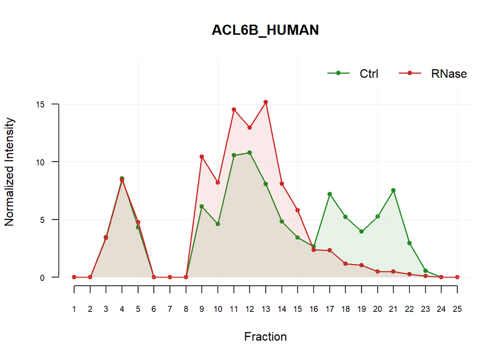

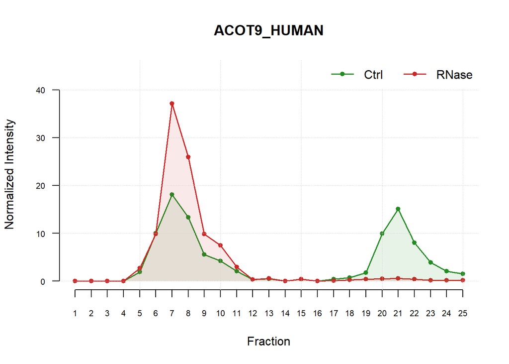

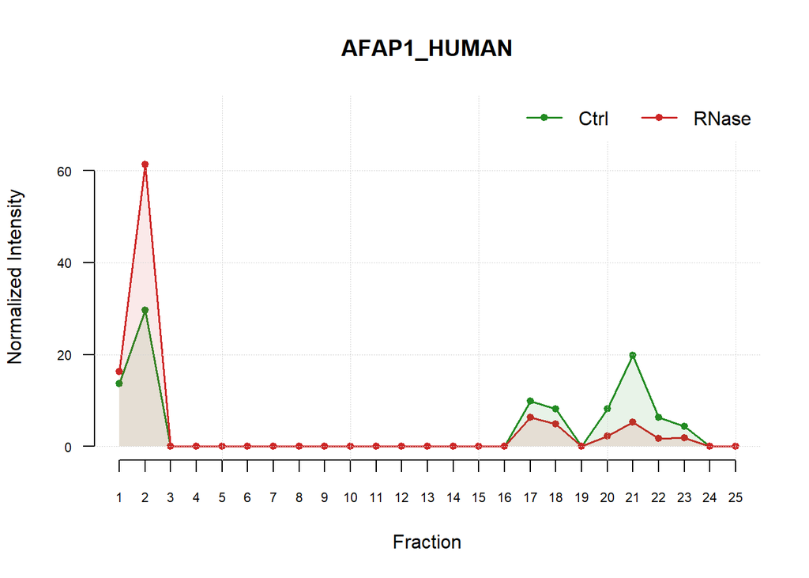

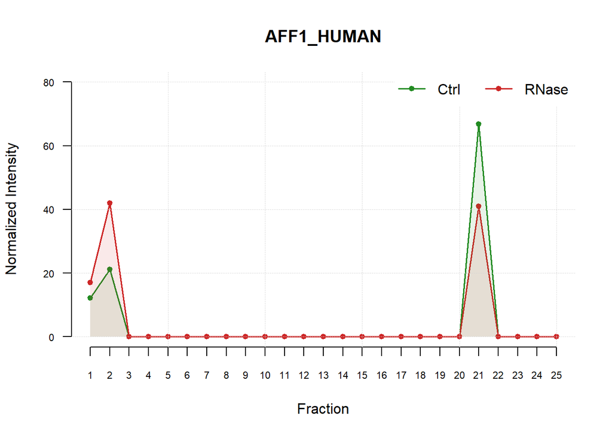

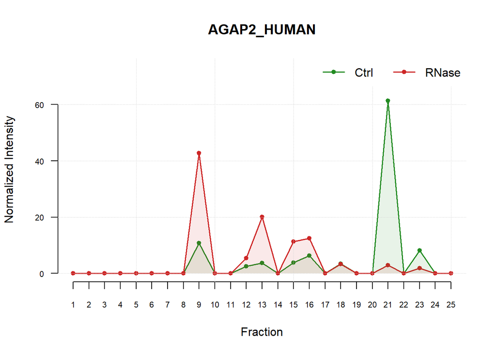

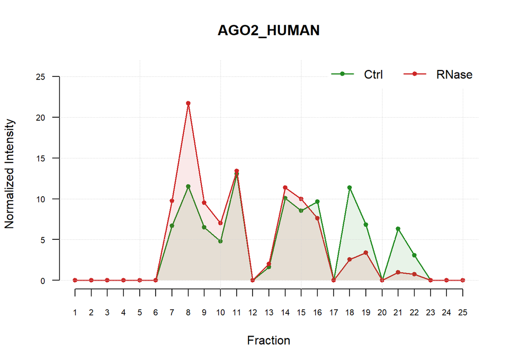

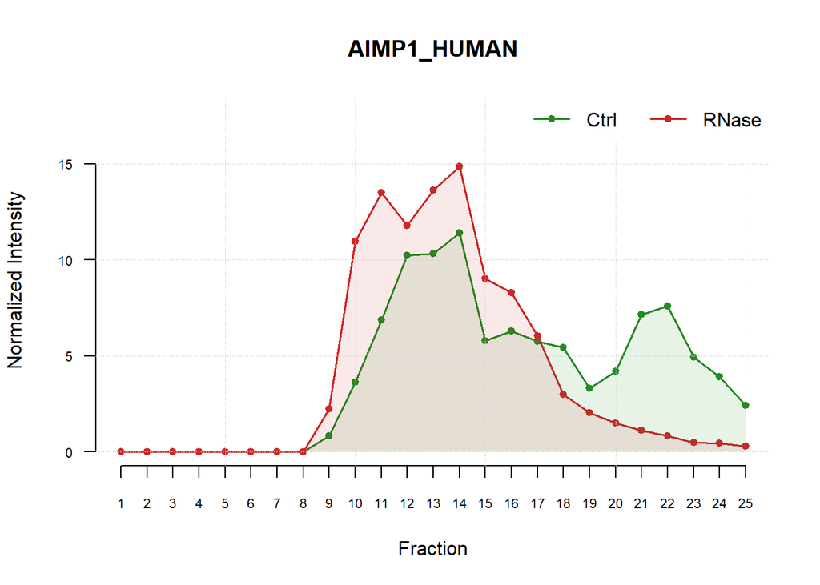

```r
#Visual inspection of a sample of T-Test positive proteins
sample_t_test_positives <-head(t_test_positives,10)
for (s in sample_t_test_positives){
  plot_protein(s)
}
```

```r
glue("From a sample of 40 T-test-positive proteins, only 2 would have been visually rejected as RBPs, corresponding to a 5% false positive rate.")
```

```
## From a sample of 40 T-test-positive proteins, only 2 would have been visually rejected as RBPs, corresponding to a 5% false positive rate.
```